# Peak Bloom Prediction Demo

# Data sanity check

1965, 2005 and 2022 data are missing, only contain 1 months data. So we remove the data.

```r
weather %>%
  group_by(year) %>%
  summarise(n = n()) %>%
  right_join(data.frame(year = c(1950:2022), n = rep(0, 73)), by = "year") %>%
  filter(is.na(n.x))
```

```
## # A tibble: 10 × 3
##     year   n.x   n.y
##    <int> <int> <dbl>
##  1  1950    NA     0
##  2  1951    NA     0
##  3  1952    NA     0
##  4  1966    NA     0
##  5  1967    NA     0
##  6  1968    NA     0
##  7  1969    NA     0
##  8  1970    NA     0
##  9  1971    NA     0
## 10  1972    NA     0
```

```r
# Use 1980s later
'%ni%' <- Negate("%in%")
weather <- weather %>% filter(year >= 1980) %>% filter(year %ni% c(2005, 2022))
```

A lot of them are missing.

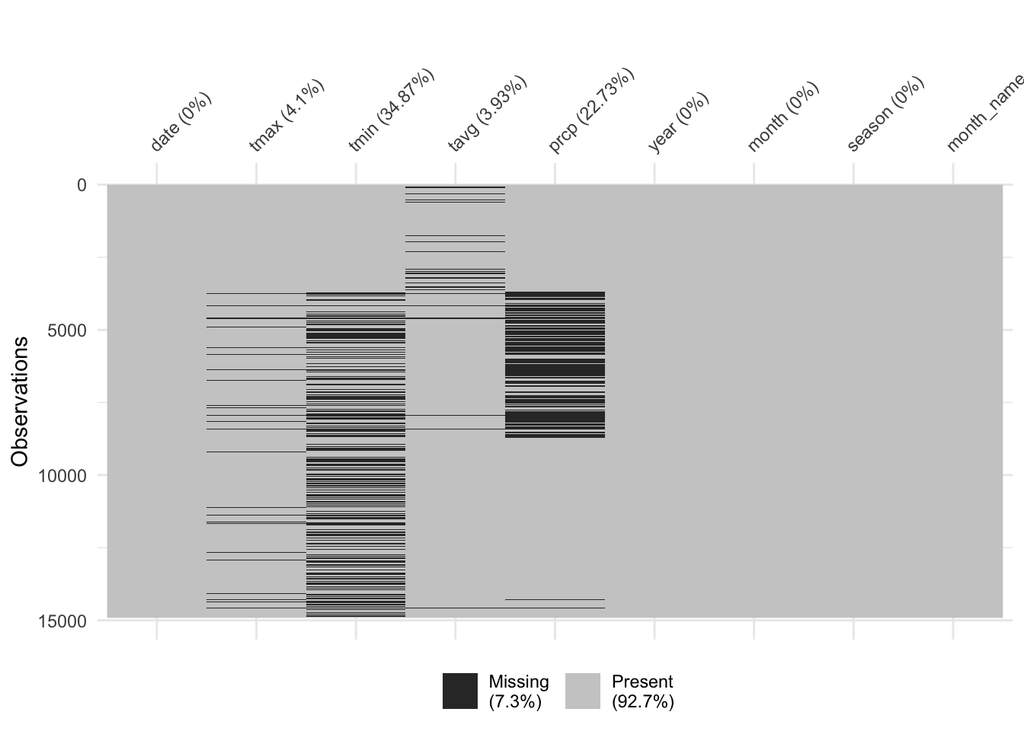

```r
vis_miss(weather)
```

## Imputation

```r
imp_temperature <- function(dat = weather, temps = "tmin") {

  for (temp in temps) {
    # Convert to time series
    temp_ori <- dat[, temp]
    temp_series <- ts(temp_ori, frequency = 1)
    dat$na <- is.na(temp_ori)

    # Use Kalman smoother to impute. Other options are also available
    dat$imp <- na_kalman(temp_series)

    n_col <- ncol(dat)
    colnames(dat)[n_col-1] <- paste0(temp, "_na")
    colnames(dat)[n_col] <- paste0(temp, "_imp")
  }
  return(dat)
}
```

```r
weather <- imp_temperature(weather, c("tmax", "tavg", "tmin"))
```

A demo of the imputation results.

```r
missing_idx <- which(is.na(weather$tmin))[1:5]
weather$date[missing_idx]
```

```
## [1] "1990-01-04" "1990-01-11" "1990-01-13" "1990-01-15" "1990-01-19"
```

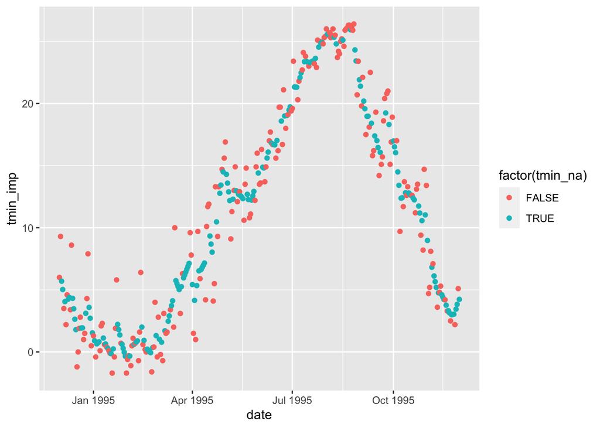

```r
# weather %>%
#   filter(year >= "1964-12-01" & year <= "1972-07-31") %>%
#   ggplot(aes(date, tmin_tmp, color = factor(tmin_na))) +
#   geom_point()

weather %>%
  filter(year >= "1994-12-01" & year <= "1995-07-31") %>%
  ggplot(aes(date, tmin_imp, color = factor(tmin_na))) +
  geom_point()
```

### Temperature

```r
get_colour <- function(df){
  colfunc <- colorRampPalette(c("blue", "red"))
  my_colour <- colfunc(12)

  df %>%
    group_by(month_name) %>%
    summarise(month_mean = mean(tmax_avg)) %>%
    arrange(month_mean) %>%
    pull(month_name) %>%
    as.integer() -> my_order

  my_colour[match(1:12, my_order)]
}
```

```r
# https://davetang.org/muse/2020/01/08/plotting-weather-data-using-r/
month_tmax <- weather %>%
  group_by(month_name, year) %>%
  summarize(tmax_avg = mean(tmax_imp),
            tmin_avg = mean(tmin_imp),
            tavg_avg = mean(tavg_imp),
            prcp_sum = sum(prcp, na.rm = TRUE),
            prcp_avg = mean(prcp, na.rm = TRUE))

my_colour <- get_colour(month_tmax %>% select(- tmin_avg, - tavg_avg))
```

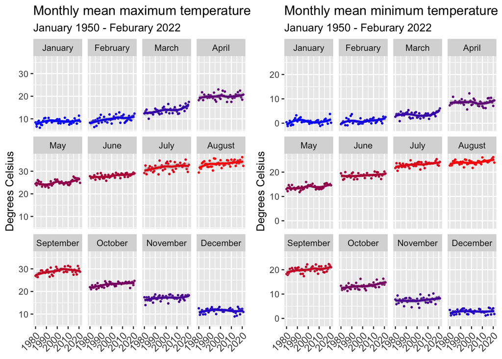

```r
a <- ggplot(month_tmax, aes(year, tmax_avg, colour = month_name)) +
  geom_point(size = 0.5) +
  geom_smooth(method = "loess") +
  theme(axis.text.x = element_text(angle = 45, hjust = 1, size = 10),
        axis.title.x = element_blank(),
        legend.position = "none") +
  scale_color_manual(values = my_colour) +
  labs(title = "Monthly mean maximum temperature",
       subtitle = "January 1950 - Feburary 2022", y = "Degrees Celsius") +
  facet_wrap(~month_name) +
  NULL

b <- ggplot(month_tmax, aes(year, tmin_avg, colour = month_name)) +
  geom_point(size = 0.5) +
  geom_smooth(method = "loess") +
  theme(axis.text.x = element_text(angle = 45, hjust = 1, size = 10),
        axis.title.x = element_blank(),
        legend.position = "none") +
  scale_color_manual(values = my_colour) +
  labs(title = "Monthly mean minimum temperature",
       subtitle = "January 1950 - Feburary 2022", y = "Degrees Celsius") +
  facet_wrap(~month_name) +
  NULL

plot_grid(a, b)
```

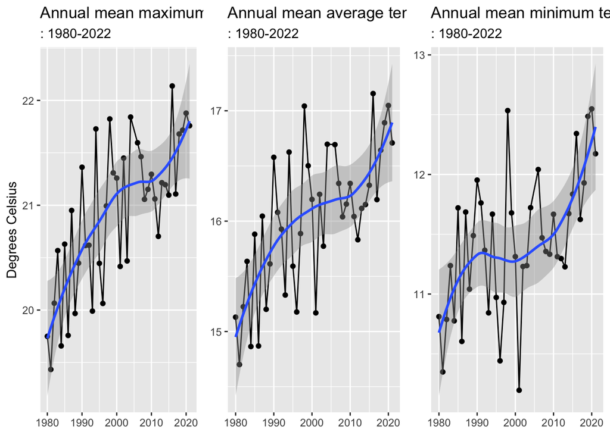

```r
a <- month_tmax %>%
  group_by(year) %>%
  summarise(year_mean = mean(tmax_avg)) %>%
  ggplot(., aes(year, year_mean)) +
    geom_point() +
    geom_line() +
    geom_smooth(method = "loess") +
    theme(axis.title.x = element_blank(),
          legend.position = "none") +
    labs(title = "Annual mean maximum temperature", subtitle = ": 1980-2022", y = "Degrees Celsius") +
    NULL

b <- month_tmax %>%
  group_by(year) %>%
  summarise(year_mean = mean(tmin_avg)) %>%
  ggplot(., aes(year, year_mean)) +
    geom_point() +
    geom_line() +
    geom_smooth(method = "loess") +
    theme(axis.title.x = element_blank(),
          axis.title.y = element_blank(),
          legend.position = "none") +
    labs(title = "Annual mean minimum temperature", subtitle = ": 1980-2022", y = "Degrees Celsius")  +
    NULL

c <- month_tmax %>%
  group_by(year) %>%
  summarise(year_mean = mean(tavg_avg)) %>%
  ggplot(., aes(year, year_mean)) +
    geom_point() +
    geom_line() +
    geom_smooth(method = "loess") +
    theme(axis.title.x = element_blank(),
          axis.title.y = element_blank(),
          legend.position = "none") +
    labs(title = "Annual mean average temperature", subtitle = ": 1980-2022", y = "Degrees Celsius")  +
    NULL

plot_grid(a, c, b, nrow = 1, rel_widths = c(1, 1, 1))
```

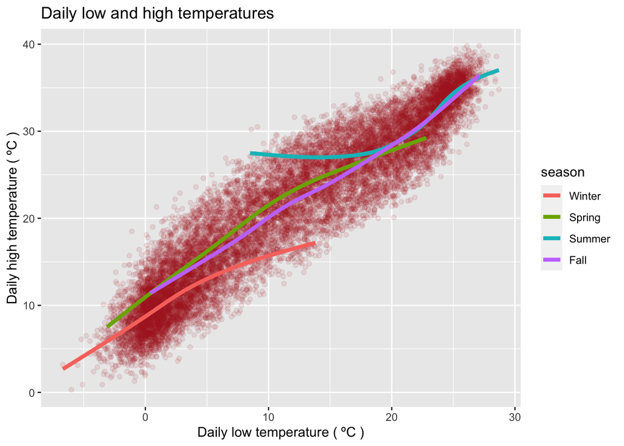

```r
# Scatter plot of low vs high daily temperatures, with a smoother curve for each season
ggplot(weather, aes(x = tmin_imp, y = tmax_imp)) +
  geom_point(colour = "firebrick", alpha = 0.1) +
  geom_smooth(aes(colour = season), se = F, size = 1.5) +
  ggtitle ("Daily low and high temperatures") +
  xlab("Daily low temperature ( ºC )") +  ylab ("Daily high temperature ( ºC )")
```

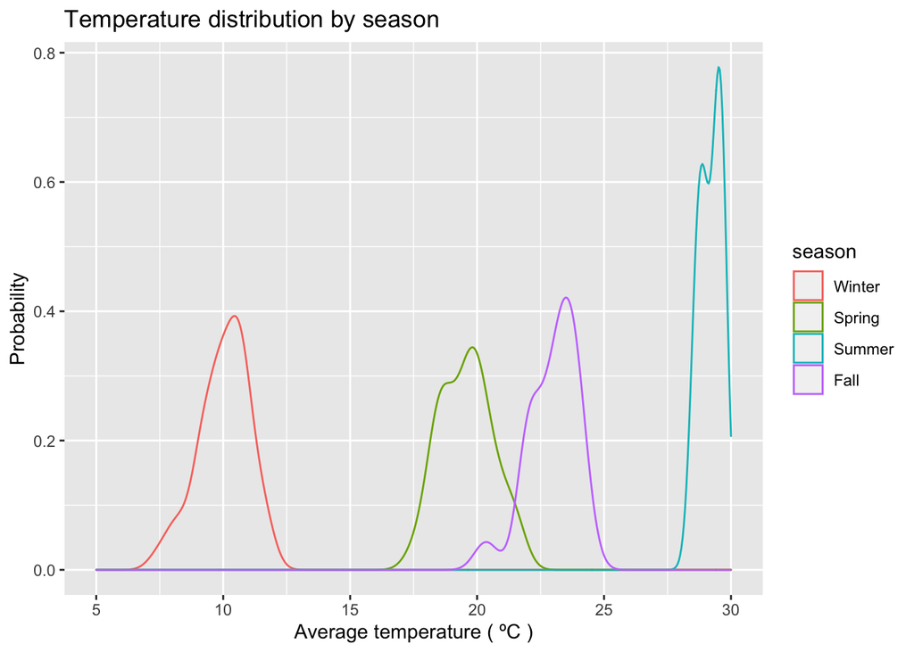

```r
# https://www.r-bloggers.com/2015/03/part-3a-plotting-with-ggplot2/
# Distribution of the average temperature by season - density plot
season_tmax <- weather %>%
  group_by(season, year) %>%
  summarize(tmax_avg = mean(tmax, na.rm= TRUE),
            tmin_avg = mean(tmin, na.rm= TRUE),
            tavg_avg = mean(tavg, na.rm= TRUE))

ggplot(season_tmax, aes(x = tmax_avg, colour = season)) +
  geom_density() +
  scale_x_continuous(limits = c(5,30), breaks = seq(5,30,5)) +
  ggtitle ("Temperature distribution by season") +
  xlab("Average temperature ( ºC )") +  ylab ("Probability")
```

#### Freezing dates

“Gardeners will keep an eye on the weather forecast, and keen gardeners will want to understand historical trends as well. An area of particular interest is the last freeze each spring. If seeds or starts are planted too early, they may succumb to a late frost. On the other end of the growing season, the first freeze each fall is a good indication of when to ensure the harvest is completed for crops that cannot withstand an early frost.”

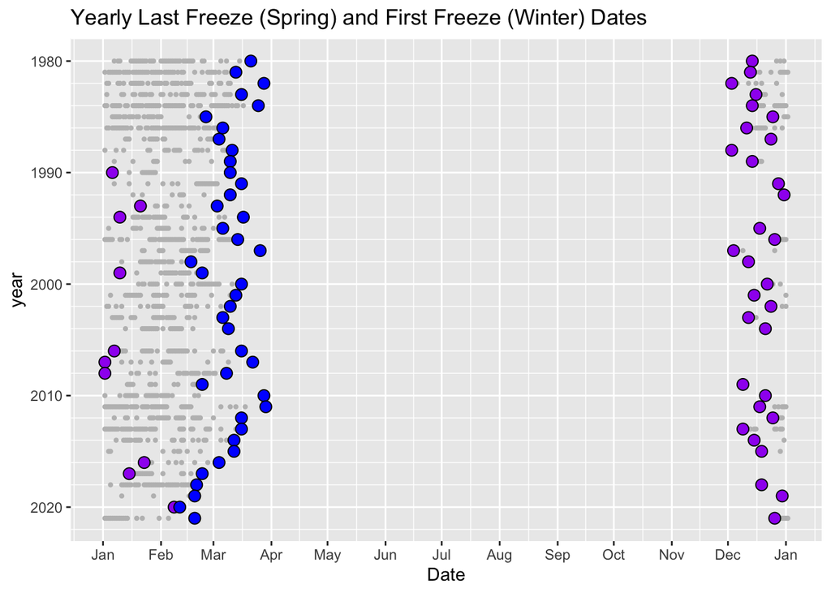

```r
library(lubridate)
# Get all freeze days, tmin < 0 C
freeze_days <- weather %>% mutate(yday = yday(date)) %>% group_by(year) %>% filter(tmin_imp <= 0)

# First and last freeze
first_freeze <- freeze_days %>% group_by(year) %>% summarise(min = min(date))
last_freeze <- freeze_days %>% group_by(year) %>% summarise(max = max(date))

first_freeze_yday <- first_freeze %>% mutate(yday = yday(min))
last_freeze_yday <- last_freeze %>% mutate(yday = yday(max))

ggplot() +
  geom_point(data = freeze_days, aes(y = year, x = as.Date(yday, origin='2022-01-01')), color = "gray", size = 0.8) +
  geom_point(data = first_freeze_yday, aes(y=year, x = as.Date(yday, origin='2022-01-01')),
             fill = "purple",shape = 21, size = 3, color = 'black') +
  geom_point(data = last_freeze_yday, aes(y=year, x = as.Date(yday,origin='2022-01-01'))
             ,fill = "blue",shape = 21, size = 3, color = 'black') +
  scale_y_reverse(breaks = seq(1950, 2022, 10), minor_breaks = seq(1944, 2022, 2)) +
  scale_x_date(date_labels = "%b", breaks = "month") +
  ggtitle("Yearly Last Freeze (Spring) and First Freeze (Winter) Dates") +
  xlab("Date")
```

Blue dots indicate the last freeze of winter Purple dots indicate the first freeze of fall Gray dots indicate days with a min temp at or below 0 tenths of degrees C

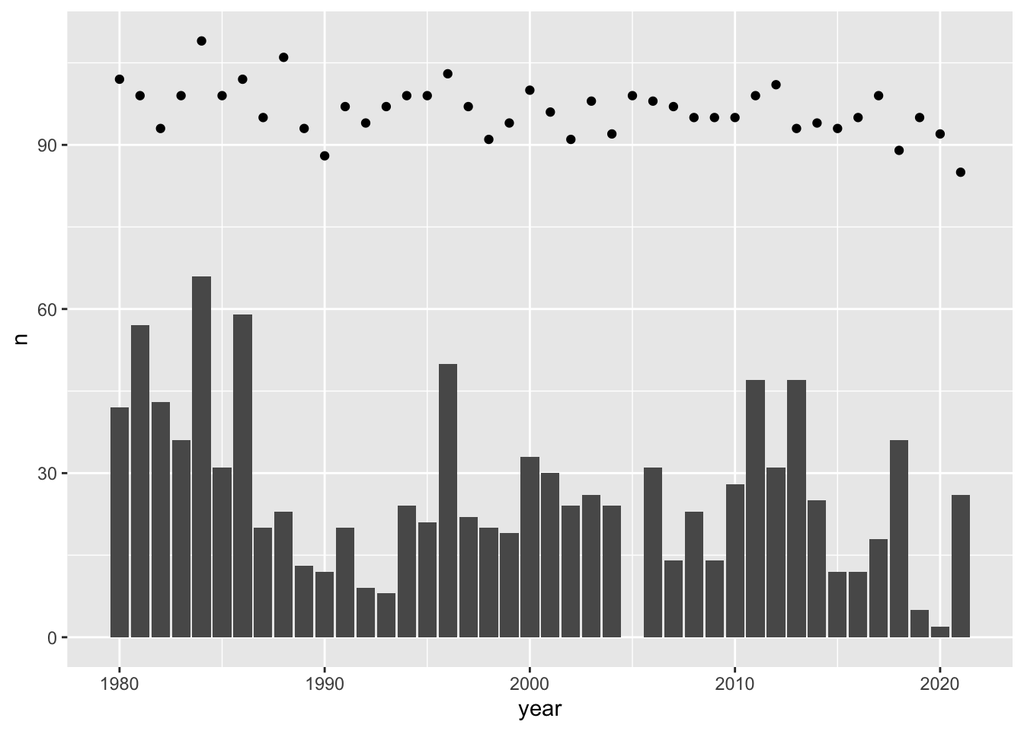

```r
# 1965 - 1972 no freezing days
freeze_days %>%
  group_by(year) %>%
  summarise(n = n()) %>%
  right_join(data.frame(year = c(1980:2021), n = rep(0, 42)), by = "year") %>%
  mutate(n = n.x + n.y) %>%
  left_join(all_jp, by = "year") %>%
  ggplot() +
  geom_bar(aes(x = year, y = n), stat = "identity") +
  geom_point(aes(x = year, y = bloom_doy))
```

```r
  xlab("Number of freezing days")
```

```
## $x
## [1] "Number of freezing days"
##
## attr(,"class")
## [1] "labels"
```

- 最近10年最后化冰日提前了，大概在2月底。
- 有的时候结冰期（紫色）退后了。

### Rainfall

有一部分rainfall是缺失的

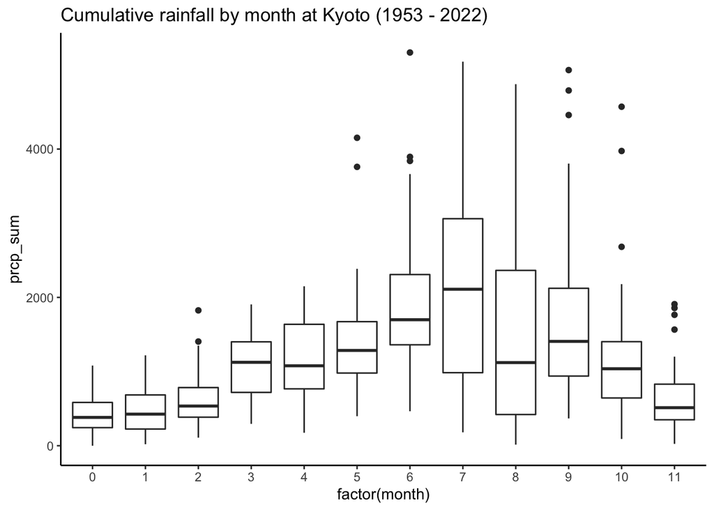

```r
weather %>%
  group_by(year, month) %>%
  summarise(prcp_sum = sum(prcp, na.rm = T)) %>%
  ggplot(aes(x = factor(month), y = prcp_sum)) +
  geom_boxplot() +
  theme_classic() +
  ggtitle("Cumulative rainfall by month at Kyoto (1953 - 2022)")
```

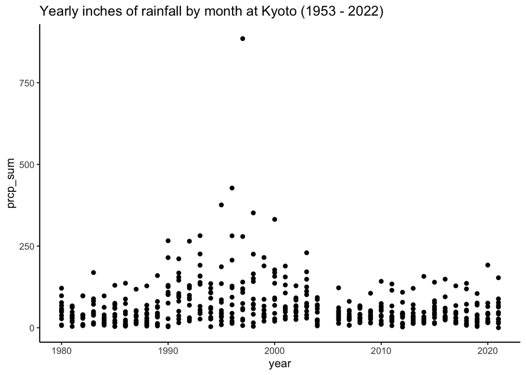

```r
weather %>%
  group_by(year, month) %>%
  summarise(prcp_sum = mean(prcp, na.rm = T)) %>%
  ggplot(aes(x = year, y = prcp_sum)) +
  geom_point() +
  theme_classic() +
  ggtitle("Yearly inches of rainfall by month at Kyoto (1953 - 2022)")
```

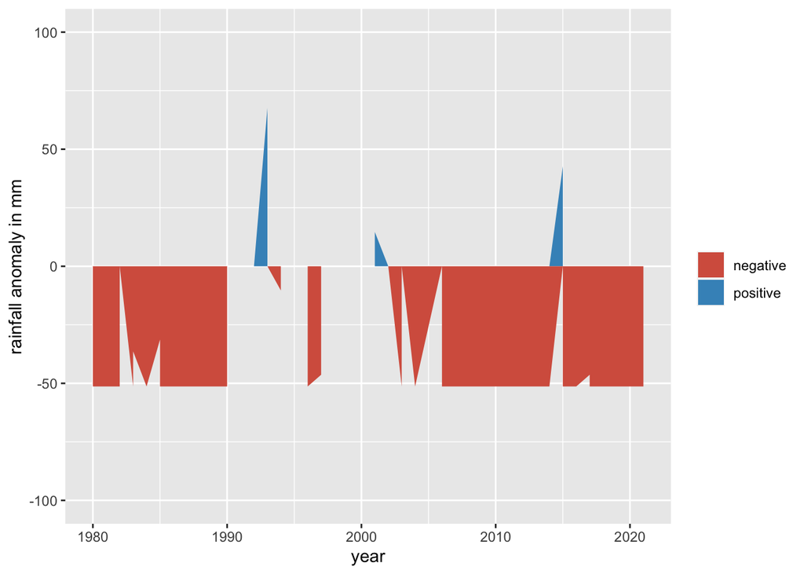

```r
weather %>%
  mutate(prcp_avg_all = mean(prcp, na.rm = T)) %>%
  mutate(prcp_pos = case_when(prcp - prcp_avg_all > 0 ~ prcp - prcp_avg_all, TRUE ~ 0),
         prcp_neg = case_when(prcp - prcp_avg_all < 0 ~ prcp - prcp_avg_all, TRUE ~ 0)) %>%
  ggplot(aes(x = year)) +
  geom_ribbon(aes(ymin = 0, ymax = prcp_pos, fill="positive")) +
  geom_ribbon(aes(ymin = prcp_neg, ymax = 0, fill="negative")) +
  scale_fill_manual(name="",values=c("#D6604D", "#4393C3")) +
  ylim(-100, 100) +
  ylab("rainfall anomaly in mm")
```

# Modeling

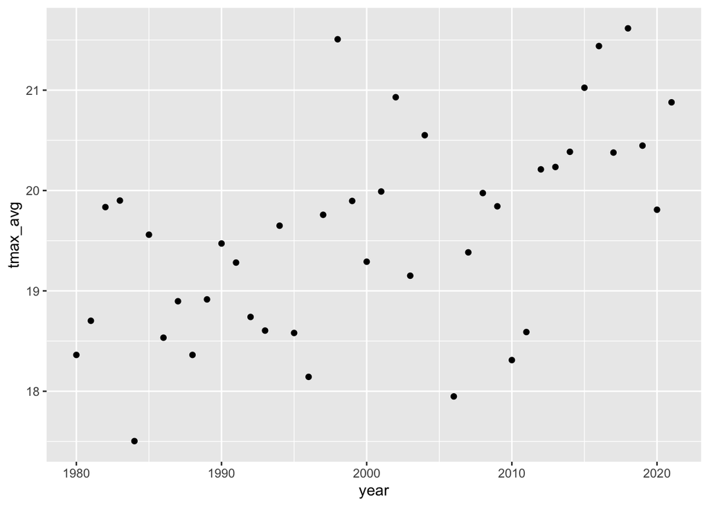

```r
spring_avg_tmp <- weather %>%
  filter(season == "Spring") %>%
  group_by(year) %>%
  summarize(tmax_avg = mean(tmax, na.rm = TRUE))

spring_avg_tmp %>%
  ggplot(aes(x = year, y = tmax_avg)) +
  geom_point()
```

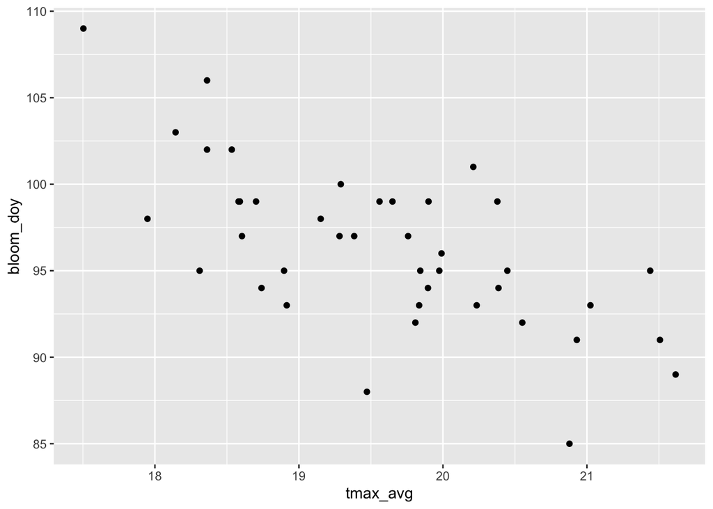

```r
tmp_date <- merge(all_jp, spring_avg_tmp, by = "year")
tmp_date %>%
  ggplot(aes(x = tmax_avg, y = bloom_doy)) +
  geom_point()
```

```r
mod2 <- lm(bloom_doy ~ tmax_avg + year, data = tmp_date)
summary(mod2)
```

```
##
## Call:
## lm(formula = bloom_doy ~ tmax_avg + year, data = tmp_date)
##
## Residuals:
##    Min     1Q Median     3Q    Max
## -8.974 -1.472  0.105  2.079  6.912
##
## Coefficients:
##              Estimate Std. Error t value Pr(>|t|)
## (Intercept) 226.62371  103.11330   2.198  0.03413 *
## tmax_avg     -2.77571    0.66566  -4.170  0.00017 ***
## year         -0.03799    0.05495  -0.691  0.49350
## ---
## Signif. codes:  0 '***' 0.001 '**' 0.01 '*' 0.05 '.' 0.1 ' ' 1
##
## Residual standard error: 3.555 on 38 degrees of freedom
## Multiple R-squared:  0.4495, Adjusted R-squared:  0.4205
## F-statistic: 15.51 on 2 and 38 DF,  p-value: 1.187e-05
```

```r
mod2 <- lm(bloom_doy ~ tmax_avg, data = tmp_date)
summary(mod2)
```

```
##
## Call:
## lm(formula = bloom_doy ~ tmax_avg, data = tmp_date)
##
## Residuals:
##     Min      1Q  Median      3Q     Max
## -8.6061 -1.3305  0.0566  2.3602  6.6365
##
## Coefficients:
##             Estimate Std. Error t value Pr(>|t|)
## (Intercept) 155.7183    10.6936  14.562  < 2e-16 ***
## tmax_avg     -3.0357     0.5456  -5.565 2.08e-06 ***
## ---
## Signif. codes:  0 '***' 0.001 '**' 0.01 '*' 0.05 '.' 0.1 ' ' 1
##
## Residual standard error: 3.531 on 39 degrees of freedom
## Multiple R-squared:  0.4426, Adjusted R-squared:  0.4283
## F-statistic: 30.96 on 1 and 39 DF,  p-value: 2.084e-06
```

## Cluster

```r
library(mclust)

mod1 <- Mclust(all_jp$bloom_doy)

summary(mod1, parameters = T)
```

```
## ----------------------------------------------------
## Gaussian finite mixture model fitted by EM algorithm
## ----------------------------------------------------
##
## Mclust X (univariate normal) model with 1 component:
##
##  log-likelihood   n df       BIC       ICL
##       -2737.624 833  2 -5488.698 -5488.698
##
## Clustering table:
##   1
## 833
##
## Mixing probabilities:
## 1
## 1
##
## Means:
## [1] 104.4538
##
## Variances:
## [1] 41.89012
```